# A Market-Basket Approach to Predict the Acute Aquatic Toxicity of Munitions and Energetic Materials

Lyle D. Burgoon, Ph.D.

US Army Engineer Research and Development Center, Environmental Laboratory

15 September, 2015

## Working Paper (v1.0)

# Problem Statement

Computational toxicology may identify and prioritize environmentally safer materials early in their development. This would allow manufacturers to focus on those chemicals and mixtures that are more likely to have beneficial qualities, saving resources over time. Computational models that are able to examine the chemical space of interest prior to lead compound generation are desirable, and may lead to the development of toxicophores that can be informative in green chemistry programs.

This study focused on developing an acute aquatic toxicology model for munitions and energetic materials of interest to the US Army. These are a special class of compounds that mostly consist of nitro-aromatics. 57 compounds were screened for lethality in a fathead minnow acute exposure to assess potential acute aquatic toxicity.

Apriori, a market-basket analysis method, was used to identify probablistic prediction rules. Market-basket analysis is typically concerned with identifying purchased products in a grocery store that predict other items an individual may purchase. For instance, a rule may predict that individuals who buy breakfast cereal and oatmeal may be more likely to also purchase milk in the same transaction. We may write the rule as “if breakfast cereal AND oatmeal => milk”, where the => represents the word “then”.

Similarly, if we consider atom-pairs within a chemical and the lethality data for fathead minnows to be all of the products within the supermarket, then we are interested in finding rules that capture these atom-pairs that are predictive of the lethality data. To do this, I discretized the fathead minnow LC50 data based on the [Globally Harmonized System of Classification and Labelling of Chemicals (GHS)][http://www.unece.org/trans/danger/publi/ghs/ghs_rev05/05files_c.html] (see Part 4, Table 4.1.1). I added a 4th category for chemicals where the LC50 was greater than 100mg/L.

The Apriori algorithm also calculates several statistics that help us interpret the rule. The confidence in the rule is the same as the conditional probability. So in the example above, the confidence is equivalent to P(Milk | Breakfast Cereal, Oatmeal). The confidence, or conditional probability of the rule, is the most important statistic, as it tells us the probability that a chemical will be within a given toxicity range given the structural characteristics in the rule.

# Methods

I tried several approaches to see if I could build a suitable model. However, the market-basket approach is the only one that really performed well. In general, there were too few chemicals in the most and least toxic classes to perform modeling.

The ChemmineR package was loaded (Cao Y, Charisi A, Cheng L, Jiang T and Girke T (2008). “ChemmineR: a compound mining framework for R.” Bioinformatics, 24(15), pp. 1733–1734. http://dx.doi.org/10.1093/bioinformatics/btn307, http://dx.doi.org/10.1093/bioinformatics/btn307), along with the arules package (Michael Hahsler, Bettina Gruen and Kurt Hornik (2005), arules - A Computational Environment for Mining Association Rules and Frequent Item Sets. Journal of Statistical Software 14/15.). In addition, I wrote a helper function to make deciphering the numeric IDs of the atom-pairs easier (decipher_ap_code).

Next, I performed the fingerprinting using the 4,096 most frequently occuring atom pairs from the Drugbank database:

Once I had the fingperints, I was interested in clustering the chemicals based on structure to get a better idea of the chemical space.

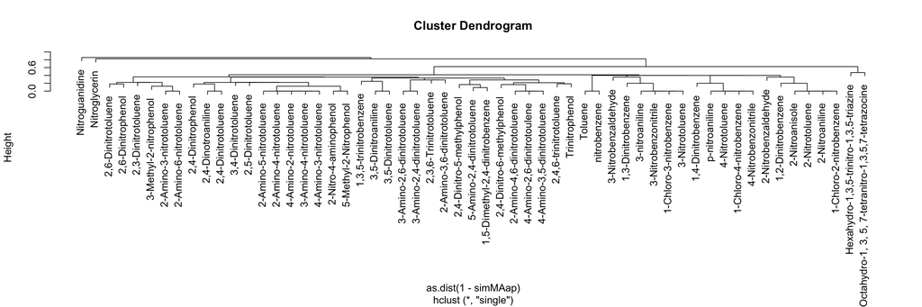

The chemical fingerprints were filtered to only keep those atom-pairs that exist within the dataset (i.e., those where at least one chemical has the atom-pair). The 4 hazard categories from the dataset are appended to the filtered fingerprint object. Note that these 4 hazard categories are the original 3 from the UN GHS system, as well as the 4th category which is for chemicals with an LC50 > 100mg/L. This matrix was then used in the apriori algorithm to generate rules.

These rules can be examined further to identify structural characteristics that are associated with the acute aquatic toxicity range.

## Results

The [UN GHS][http://www.unece.org/trans/danger/publi/ghs/ghs_rev05/05files_c.html] has 3 categories:

1. Category 1 (CAT1): 96hr (acute) fish LC50: < 1mg/L
2. Category 2 (CAT2): 96hr (acute) fish LC50: 1mg/L < x <= 10mg/L
3. Category 3 (CAT3): 96hr (acute) fish LC50: 10mg/L < x <= 100mg/L

For our analysis we also considered a 4th category, that is, those chemicals whose 96hr (acute) fish LC50 > 100mg/L. We denote this as Category 4 (CAT4). As can be seen in the following figure, CAT3 has the most chemicals, followed by CAT2, CAT4 and finally CAT1. In fact, the number of chemicals in CAT1 and CAT4 is so small that it is difficult to generate rules (we’ll see that shortly).

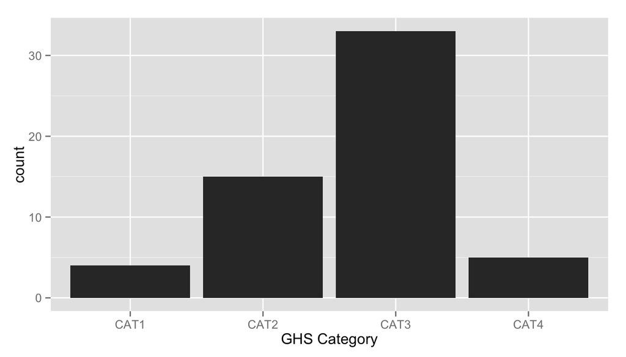

Across all 3,390 rules, there is a wide range of confidence, lift, and support (see the following plot). Generally, we are most interested in those rules with the largest lift, and then those with the highest confidence amongst those. Support is not as useful in this context, as it measures the number of times the rule occurs in the entire database. It is possible that some of our most useful rules are those which occur relatively infrequently within the database. Those structures that are more likely to occur in the database are also those that are the least likely to contain a high amount of information overall. This is similar to the concept that if you are looking for words that best represent a body of work, you are not likely to use the most frequent words, as those are likely to be low information words such as “the”, “a”, and “an”.

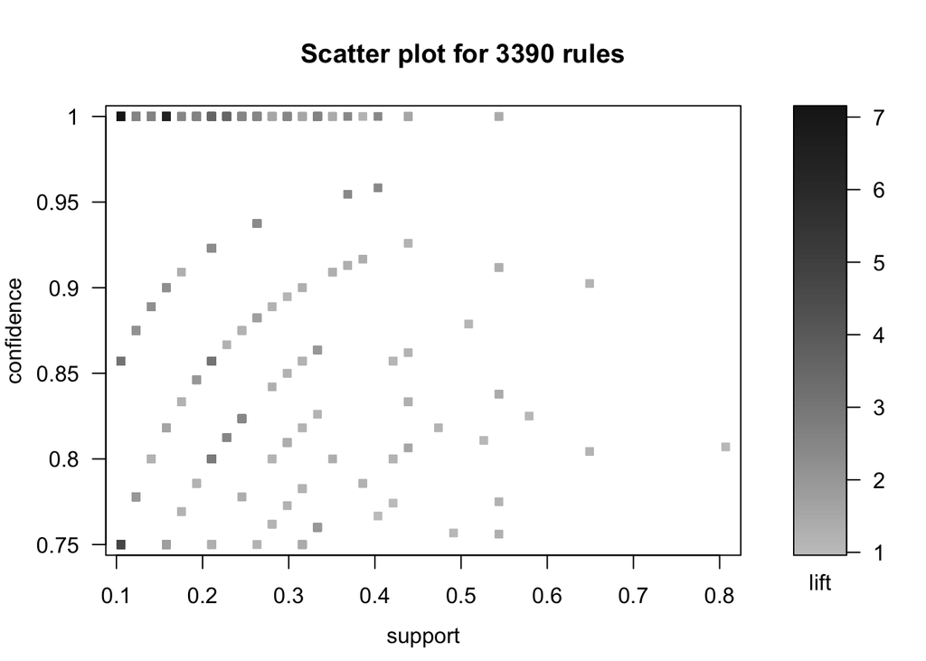

The Apriori algorithm was not able to identify any rules for CAT1 with a confidence greater than or equal to 75%. Thus, it will not be possible for the current model to assess if a chemical is within CAT1. This represents a data gap; however, this may also reflect the fact that this chemical space does not exhibit acute fish LC50s in the less than 1mg/L range.

```
## [1] TRUE
```

Apriori identified 2 rules for CAT2.

```
##   lhs              rhs      support confidence lift
## 1 {53824505984,
##    69933794432} => {CAT2} 0.1052632       0.75 2.85
## 2 {54897200256,
##    53824505984,
##    69933794432} => {CAT2} 0.1052632       0.75 2.85
```

Apriori identified 27 rules for CAT3.

```
##    lhs              rhs      support confidence     lift
## 1  {54896151680,
##     53822408833} => {CAT3} 0.1578947  0.7500000 1.295455
## 2  {53822408832,
##     54896151680,
##     53822408833} => {CAT3} 0.1578947  0.7500000 1.295455
## 3  {53823457408,
##     54896151680,
##     53822408833} => {CAT3} 0.1578947  0.7500000 1.295455
## 4  {53822408832,
##     54896151680,
##     69799576576} => {CAT3} 0.1052632  0.7500000 1.295455
## 5  {53822408832,
##     54896151680,
##     69933794432} => {CAT3} 0.1052632  0.7500000 1.295455
## 6  {53822408832,
##     53823457408,
##     54896151680} => {CAT3} 0.3157895  0.7500000 1.295455
## 7  {53822408832,
##     53823457408,
##     54896151680,
##     53822408833} => {CAT3} 0.1578947  0.7500000 1.295455
## 8  {53822408832,
##     54896151680,
##     69799576576,
##     69933794432} => {CAT3} 0.1052632  0.7500000 1.295455
## 9  {54897200256,
##     53822408832,
##     54896151680,
##     69799576576} => {CAT3} 0.1052632  0.7500000 1.295455
## 10 {54897200256,
##     53822408832,
##     54896151680,
##     69933794432} => {CAT3} 0.1052632  0.7500000 1.295455
## 11 {54898248832,
##     53822408832,
##     54896151680,
##     53824505984} => {CAT3} 0.1578947  0.7500000 1.295455
## 12 {54898248832,
##     53823457408,
```

[output cut: 56 more lines]

```
##     54897200256,
##     53822408832,
##     53823457408,
##     54896151680} => {CAT3} 0.1578947  0.7500000 1.295455
## 26 {54897200256,
##     53822408832,
##     53823457408,
##     54896151680,
##     53824505984} => {CAT3} 0.1578947  0.7500000 1.295455
## 27 {54898248832,
##     54897200256,
##     53822408832,
##     53823457408,
##     54896151680,
##     53824505984} => {CAT3} 0.1578947  0.7500000 1.295455
```

Apriori identified 0 rules for CAT4.

Our analysis/model provides the confidence, or probability, that a combination of structural characteristics is associated with a particular GHS category. We are able to build tables of structural alerts based on the chemical structures in the rules and their association with a particular GHS category. In addition, the model can be queried with a structure, and we can identify the likely GHS category based on structure alone using a combination of the lift and confidence.

Let’s take the example of 2,5-dinitrotoluene. It has the following smiles code: CC1=C(C=CC(=C1)[N+](=O)[O-])[N+](=O)[O-]

That results in the following fingerprint pattern:

```
## 54898248832 54897200256 53822408832 53823457408 54896151680 53824505984
##           1           1           1           1           1           1
## 53822408833 53823457409 54898248833 54896151681 54897200257 53824505985
##           0           0           0           0           0           0
## 53689239552 53822408834 53823457410 54897200258 53825554560 53822408835
##           0           0           0           0           0           0
## 54896151682 53691336704 53823457411 53824505986 53689239553 53691336705
##           0           0           0           0           0           0
## 53689239554 69797479424 69932745856 69799576576 53823457412 53689239555
##           0           0           0           0           0           0
## 69798528000 70870173696 69935891584 69933794432 69800625152 69934843008
##           0           0           0           0           1           1
## 69801673728 69797479425 70871222272 69799576577 52617593856 69800625153
##           0           0           0           0           0           0
## 69801673729 70870173697 69935891585 69934843009 69799576578 69933794433
##           0           0           0           0           0           0
## 63355022336 63352925184 69799576579        CAT1        CAT2        CAT3
##           0           0           0           0           1           0
##        CAT4
##           0
```

Querying the model database can be accomplished through code such as the following, which results in the identification of rules that are associated with this chemical:

```
##    lhs              rhs      support confidence     lift
## 1  {53822408832,
##     53823457408,
##     54896151680} => {CAT3} 0.3157895  0.7500000 1.295455
## 2  {54897200256,
##     53822408832,
##     53823457408,
##     54896151680} => {CAT3} 0.2456140  0.7777778 1.343434
## 3  {54896151680,
##     53822408833} => {CAT3} 0.1578947  0.7500000 1.295455
## 4  {53822408832,
##     54896151680,
##     53822408833} => {CAT3} 0.1578947  0.7500000 1.295455
## 5  {53823457408,
##     54896151680,
##     53822408833} => {CAT3} 0.1578947  0.7500000 1.295455
## 6  {53822408832,
##     53823457408,
##     54896151680,
##     53822408833} => {CAT3} 0.1578947  0.7500000 1.295455
## 7  {54898248832,
##     53822408832,
##     54896151680,
##     53824505984} => {CAT3} 0.1578947  0.7500000 1.295455
## 8  {54898248832,
##     53823457408,
##     54896151680,
##     53824505984} => {CAT3} 0.1578947  0.7500000 1.295455
## 9  {54898248832,
##     54897200256,
##     53822408832,
##     53824505984} => {CAT3} 0.1578947  0.7500000 1.295455
## 10 {54898248832,
##     54897200256,
##     53823457408,
##     53824505984} => {CAT3} 0.1578947  0.7500000 1.295455
## 11 {54898248832,
##     53822408832,
##     53823457408,
##     54896151680} => {CAT3} 0.1578947  0.7500000 1.295455
```

[output cut: 61 more lines]

```
##     69799576576,
##     69933794432} => {CAT3} 0.1052632  0.7500000 1.295455
## 27 {54897200256,
##     53822408832,
##     54896151680,
##     69799576576} => {CAT3} 0.1052632  0.7500000 1.295455
## 28 {54897200256,
##     53822408832,
##     54896151680,
##     69933794432} => {CAT3} 0.1052632  0.7500000 1.295455
## 29 {54897200256,
##     53822408832,
##     54896151680,
##     69799576576,
##     69933794432} => {CAT3} 0.1052632  0.7500000 1.295455
```

What we want to find is a rule that only has atom-pairs in our compound, and that also has the highest lift and confidence. To do this, I filtered out the entire rule set to find rules whose atom-pairs are represented in the compound. Then I identified the rules that only had atom-pairs represented in 2,5-dinitrotoluene. Finally, I selected the rule that had the largest lift.

```
##                                                            rules  support
## 2314 {54897200256,53822408832,53823457408,54896151680} => {CAT3} 0.245614
##      confidence     lift
## 2314  0.7777778 1.343434
```

The rule {54897200256,53822408832,53823457408,54896151680} => {CAT3} means that there are 4 atom-pairs that have a 78% chance of accurately predicting a chemical as being in GHS Category 3 (fish acute LC50 between 10mg/L and 100mg/L). By performing a few more queries, it is possilbe to identify what these atom-pairs are as a first attempt to define a potential toxicophore.

```
## [1] "C [3 neighbor(s),1 pi electrons]<---2--->C [3 neighbor(s),1 pi electrons]"
```

```
## [1] "C [2 neighbor(s),1 pi electrons]<---1--->C [2 neighbor(s),1 pi electrons]"
```

```
## [1] "C [2 neighbor(s),1 pi electrons]<---2--->C [2 neighbor(s),1 pi electrons]"
```

```
## [1] "C [3 neighbor(s),1 pi electrons]<---1--->C [3 neighbor(s),1 pi electrons]"
```

Putting these atom-pairs together, and using knowledge of the chemical space, it appears that the toluene structure is what is driving the model to categorieze this chemical as CAT3.

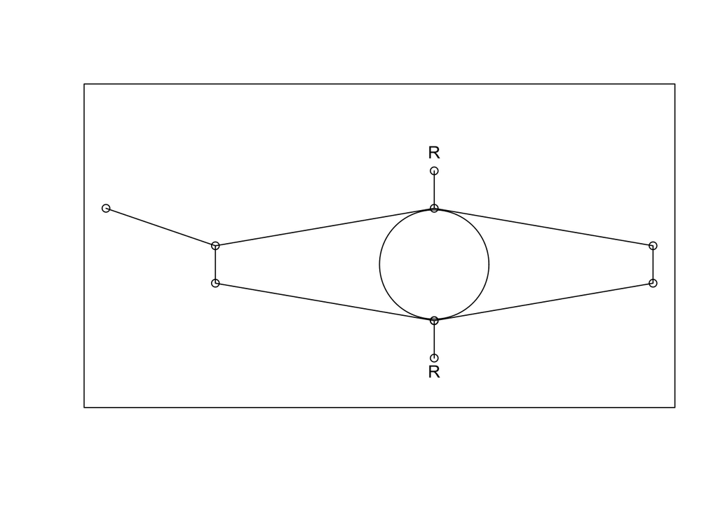

A more formal analysis would be to look at the rules with the largest lift for each category and use those as a starting point to define toxicophores. For CAT2 the following rule has the largest lift:

```
##   lhs              rhs      support confidence lift
## 1 {53824505984,
##    69933794432} => {CAT2} 0.1052632       0.75 2.85
## 2 {54897200256,
##    53824505984,
##    69933794432} => {CAT2} 0.1052632       0.75 2.85
```

Since atom-pairs 53824505984 and 69933794432 occur in both rules, and the rule with 54897200256 does not have any different support, confidence or lift, it is likely that 54897200256 does not add any value to the potential toxicophore. Thus, the toxicophore analysis will center only on atom-paris 53824505984 and 69933794432 (note that different componds are used as not all atom-pairs are represented in all compounds).

```
## [1] "C [2 neighbor(s),1 pi electrons]<---3--->C [2 neighbor(s),1 pi electrons]"
```

```
## [1] "O [1 neighbor(s),1 pi electrons]<---6--->O [1 neighbor(s),1 pi electrons]"
```

These two rules set up and intersting toxicophore where, based on the chemical space, a nitro group is within 3 carbon atoms of each other on an aromatic ring.

For CAT3 we do the same analysis as for CAT2.

```
##    lhs              rhs      support confidence     lift
## 1  {54897200256,
##     53822408832,
##     53823457408,
##     54896151680} => {CAT3} 0.2456140  0.7777778 1.343434
## 2  {54896151680,
##     53822408833} => {CAT3} 0.1578947  0.7500000 1.295455
## 3  {53822408832,
##     54896151680,
##     53822408833} => {CAT3} 0.1578947  0.7500000 1.295455
## 4  {53823457408,
##     54896151680,
##     53822408833} => {CAT3} 0.1578947  0.7500000 1.295455
## 5  {53822408832,
##     54896151680,
##     69799576576} => {CAT3} 0.1052632  0.7500000 1.295455
## 6  {53822408832,
##     54896151680,
##     69933794432} => {CAT3} 0.1052632  0.7500000 1.295455
## 7  {53822408832,
##     53823457408,
##     54896151680} => {CAT3} 0.3157895  0.7500000 1.295455
## 8  {53822408832,
##     53823457408,
##     54896151680,
##     53822408833} => {CAT3} 0.1578947  0.7500000 1.295455
## 9  {53822408832,
##     54896151680,
##     69799576576,
##     69933794432} => {CAT3} 0.1052632  0.7500000 1.295455
## 10 {54897200256,
##     53822408832,
##     54896151680,
##     69799576576} => {CAT3} 0.1052632  0.7500000 1.295455
## 11 {54897200256,
##     53822408832,
##     54896151680,
##     69933794432} => {CAT3} 0.1052632  0.7500000 1.295455
## 12 {54898248832,
##     53822408832,
```

[output cut: 56 more lines]

```
##     54897200256,
##     53822408832,
##     53823457408,
##     54896151680} => {CAT3} 0.1578947  0.7500000 1.295455
## 26 {54897200256,
##     53822408832,
##     53823457408,
##     54896151680,
##     53824505984} => {CAT3} 0.1578947  0.7500000 1.295455
## 27 {54898248832,
##     54897200256,
##     53822408832,
##     53823457408,
##     54896151680,
##     53824505984} => {CAT3} 0.1578947  0.7500000 1.295455
```

In this case, we return one top rule, and that is {54897200256, 53822408832, 53823457408, 54896151680} => {CAT3}. These atom-pairs are:

```
## [1] "C [3 neighbor(s),1 pi electrons]<---2--->C [3 neighbor(s),1 pi electrons]"
```

```
## [1] "C [2 neighbor(s),1 pi electrons]<---1--->C [2 neighbor(s),1 pi electrons]"
```

```
## [1] "C [2 neighbor(s),1 pi electrons]<---2--->C [2 neighbor(s),1 pi electrons]"
```

```
## [1] "C [3 neighbor(s),1 pi electrons]<---1--->C [3 neighbor(s),1 pi electrons]"
```

This toxicophore, based on the chemical space, is going to look something like:

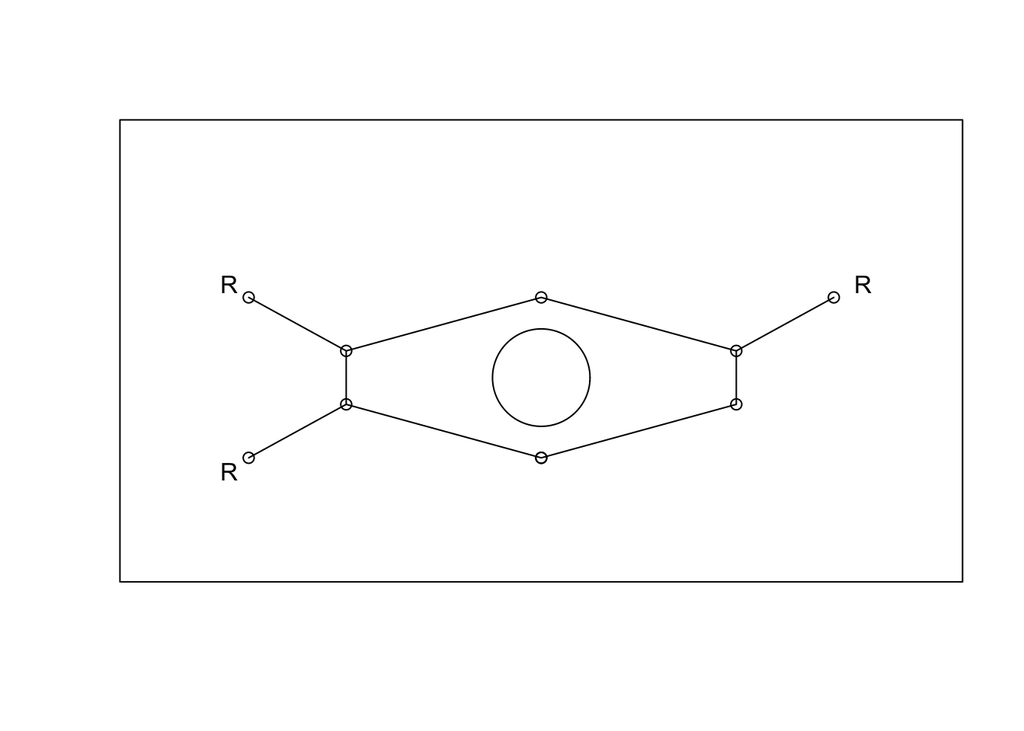

The final examination of this analysis is to identify how well the model does at predicting a chemical’s GHS category. For this, we need to compare the predicted GHS Category to the GHS Category that we assigned based on the acute fathead minnow LC50 data. For this analysis I am only using the highest confidence rules for the predictions.

```
##
##        CAT1 CAT2 CAT3 CAT4
##   CAT2    0    6    2    0
##   CAT3    2    3   18    1
```

Overall, the model does fairly well. Next, a 5-fold cross-validation was performed to assess the model’s ability to accurately predict GHS categories.

[output not shown]

[output cut: 45 more lines]

[output not shown]

```
##    class_rate misclass_rate
##     0.7404698     0.2595302
```

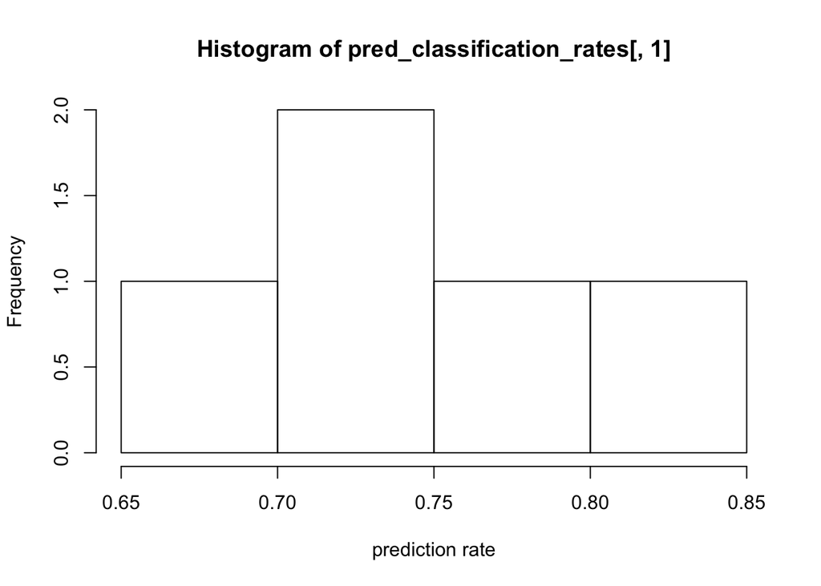

The rate at which chemicals are classified into the GHS categories is approximately 74%, with a misclassification rate of approximateliy 26%. Given that there are 4 possible classes, the model does fairly well. However, it should be noted that this is only for those chemicals which the model is capable of producing a classification for.

The surrogate approach was able to assign GHS categories for all of the chemicals lacking a model prediction. This does fairly well overall. There was one misclassification of CAT1 as CAT2, no misclassifications of CAT2, 8 misclassifications of CAT3 as CAT2, with 5 CAT3 correct classifications, and all 4 CAT4 chemicals were misclassified as CAT2 or CAT3. This is not surprising due to the relatively low numbers of chemicals in CAT1 and CAT4.

```
##
##        CAT1 CAT2 CAT3 CAT4
##   CAT1    1    1    0    0
##   CAT2    0    6    0    0
##   CAT3    0    8    5    0
##   CAT4    0    2    2    0
```

# Discussion

The market basket approach was able to identify some useful rules that may help to identify potential toxicophores that should be considered when designing novel munitions and energetics. This analysis has identified that toluene structures tend to be associated with chemicals with decreased acute fish lethality, whereas chemicals that have a nitro group within 3 carbon atoms of each other on an aromatic ring tend to have increased acute fish leathality. A key advantage of the market basket approach is that additional compounds can be added easily to the analysis, and new toxicophores can be identified that may be more robust than the ones used in this dataset.

In addition, I found that there is generally good agreement between the predictions and ground truth for chemical GHS categories. However, it should also be noted that 25/57 of the compounds were not able to be categorized by the model directly, due to a lack of rules that contained atom-pairs for these compounds. In this case, a surrogate approach was used to predict the GHS category.

The surrorage approach worked rather well. Although there were some misclassifications, overall, the approach worked as expected, with a generally conservative GHS assignment being given when misclassification occured. This suggests that when the model is not capable of predicting, the surrogate approach can be used to give a general idea of GHS category.

Overall, the modeling and surrogate approaches appear to work reasonably well. Considering the alternative of having no information available at all, or waiting on acute fish studies, the modeling and surrogate approaches will allow for some early decisions to be made. In addition, the modeling approach was able to identify two toxicophores which tend to be associated with CAT2 and CAT3. At present, the dataset is small, and thus I would recommend that further analysis be conducted to identify if there is increased evidence supporting these toxicophores association with acute lethality in the fathead minnow model.

It should also be noted that future work should expand this database beyond this relatively small list of chemicals, and should seek additional endpoints, especially chronic and non-lethal endpoints.

Overall, this initial modeling effort was successful at addressing the problem. These modeling and surrogate efforts will be improved over time as the database is expanded.